# Seasonal Model

©Alexander Doynikov,dep. CS, MSU

September 15, 2022

# 1 Сезонные ARMA модели

При помощи общей модели авторегресии-скользящего среднего
$$φ(B)x_{t}=θ(B)\epsilon_{t}$$
можно вполне адекватно описывать достаточно широкий класс временных рядов. Но если задаться построением наиболее экономичной (с точки зрения количества оцениваемых параметров) модели, то в некоторых случаях небольшая ее модификация позволяет значительно уменьшить число параметров модели. В первую очередь это касается так называемых сезонных временных рядов, в которых наблюдается определенное сходство в поведении наблюдений, разделенных по времени на фиксированный пероид времени s. Пусть во временном ряде $z_{t}$ нам удалось связать наблюдения, отстоящие друг от друга на время s в модель
$$Φ_{P}(B^{s})∇_{s}^{D}z_{t}=Θ_{Q}(B^{s})a_{t} (*)$$
Где $Φ_{P}(B^{s})$ и $Θ_{Q}(B^{s})$ полиномы степени $P,Q$ соответственно вида
$$Φ_{P}(B^{s})=1-Φ_1B^{s}-...-Φ_{P}B^{Ps}$$
$$Θ_{Q}(B^{s})=1-Θ_1B^{s}-...-Θ_{Q}B^{Qs}$$
которые удовлетворяют условиям стационарности и обратимости, a
$$∇_{s}^{D}=(1-B^{s})^{D}$$
оператор сезонной разности порядка $D$

Ошибки $a_{t}$ здесь не обязательно должны быть некоррелированными, так как наличие связи между переменными через период времени s не означает, что нет связи между соседними значениями ряда $z_{t}$ и $z_{t-1}$ или переменными, отстоящими друг от друга на два, три и т.д. моментами времени. Чтобы учесть и эту связь мы вводим еще одну модель
$$φ(B)∇^{d}a_{t}=θ(B)\epsilon_{t}$$

где $\epsilon_{t}$- уже белый шум, а $φ(B)$ и $θ(B)$ полиномы по $B$ степени $p$ и $q$ соответсвенно, также удовлетворяющие условиям стационарности и обратимости. Подставляя последнее выражение в (*) получим окончательную общую модель
$$φ(B)Φ_{P}(B^{s})∇^{d}∇_{s}^{D}z_{t}=Θ_{Q}(B^{s})θ(B)\epsilon_{t}$$
(**)

которую и называют сезонной моделью авторегресии проинтегрированного скользящего среднего и обозначают $SARMA(p,d,q)(P,D,Q)$

Таким образом мы задаем мультипликативную модель сезонности.

### 1.0.1 Идентификация сезонных моделей

#### 1.0.1.1 Сезоннные модели скользяшего среднего

Для идентификация сезонных моделей также широко используется АКФ и ЧАКФ. ввeдем понятие производящей функции автокорреляций. `Определение.` Производящей функцией АКФ называется функция вида
$$\gamma(z)=
\sum_{k=-\infty}^{\infty}c_kz^k$$
Справедливо следующее утверждение. Если временной ряд задан в виде моделт линейного фильтра типа скользящего среднего
$$x_t = \Psi(B)\epsilon(t)=
(1+\Psi_1B+\Psi_2B^2+.....)\epsilon_t$$
тогда
$$\gamma(z)=\sigma^2\Psi(B)\Psi(B^{-1})$$

Для выяснения характера поведения ACF и PACF нам поможет тот факт, что производящая функция автоковариаций процесса заданного мультипликативно равна произведению производящих функций его компонент. Т.е. если компоненты
$$φ(B)∇^{d}a_{t}=θ(B)\epsilon_{t}$$
$$\Phi_{P}(B^{s})\Delta^{D}z_t=\Theta_{Q}(B^s)a_t$$
имеют производящие функции АКФ $γ(B),Γ(B)$ соответсвенно, то производящая функция автоковариаций процесса $z_{t}$ равна $γ(B)Γ(B)$

Проще всего найти выражение для модели сезонного скользящего среднего.
$$x_t=\Theta_Q(B^s)\theta_q(B)\epsilon_t$$
. Для такой модели производящие функции автокорреляций равны
$$γ(B)=\sigma^2_{\epsilon}\theta_q(B)\theta(B^{-1})$$
,
$$\Gamma(B)=\sigma^2_{a}
\Theta_Q(B^s)\Theta_Q(B^{-s})$$
Cледовательно для всего процесса она будет
$$C(B)=\sigma^2_{\epsilon}\sigma^2_{a}\theta_q(B)\Theta_Q(B^s)\theta_q(B^{-1})\Theta_Q(B^{-s})$$

### 1.0.2 Пример SARMA(0,0,1)(0,0,1)

В этой модели $\theta_q(B)=1 - \theta_1B$,$\Theta_Q(B^s)=1 - \Theta_1B^s$ поэтому
$$c(B)=
\sigma^2_{\epsilon}\sigma^2_{a}(1 - \theta_1B)(1 - \theta_1B^{-1})(1 -
\Theta_1B^s)(1 - \Theta_1B^{-s})$$
Перемножая полиномы, получим, что отличны от нуля будут коэффициенты при степени $0,1,,...,s-1,s,s+1$

```r
  library(polynom)
  season <- 7
  theta1 <- 0.6
  Theta1 <- 0.8
  ma <- c(1,theta1)
  sma <- c(1,rep(0,season-1),Theta1)
  ma <- as.polynomial(ma)
  sma <- as.polynomial(sma)
  ma
```

```
## 1 + 0.6*x
```

```r
  sma
```

```
## 1 + 0.8*x^7
```

```r
  sma_ma <- ma *sma
  sma_ma
```

```
## 1 + 0.6*x + 0.8*x^7 + 0.48*x^8
```

```r
  ma_vec <- sma_ma[2:length(sma_ma)]
  ma_vec
```

```
## [1] 0.60 0.00 0.00 0.00 0.00 0.00 0.80 0.48
```

Оценим ACF,PACF по модели

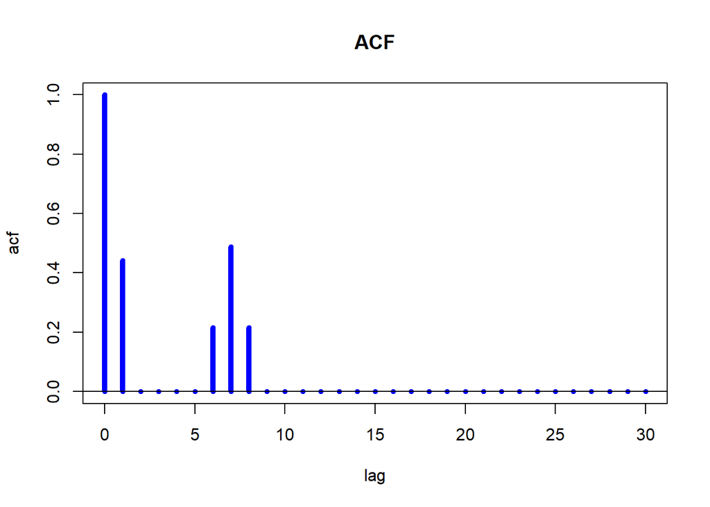

```r
  acf <- ARMAacf(ma=ma_vec,lag.max = 30,pacf = FALSE)
  pacf <- ARMAacf(ma=ma_vec,lag.max = 30,pacf = TRUE)
  m <- length(acf)
  matplot(0:(m-1),acf,type= 'h',main = 'ACF',col = 'blue',lwd = 5,xlab = 'lag',ylab='acf')
  abline(h = 0,untf = TRUE,col = 'black')
```

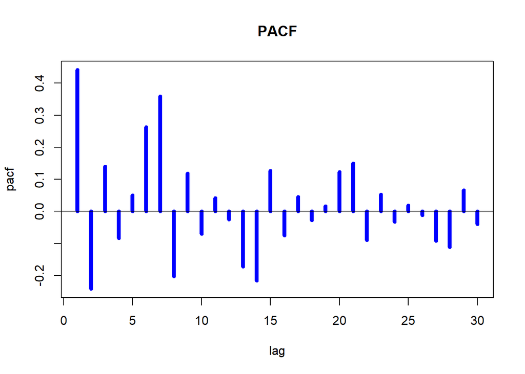

```r
  matplot(pacf,type= 'h',main = 'PACF',col = 'blue',lwd = 5,xlab =  'lag',ylab='pacf')
        abline(h = 0,untf = TRUE,col = 'black')
```

Смоделируем сезонный ряд

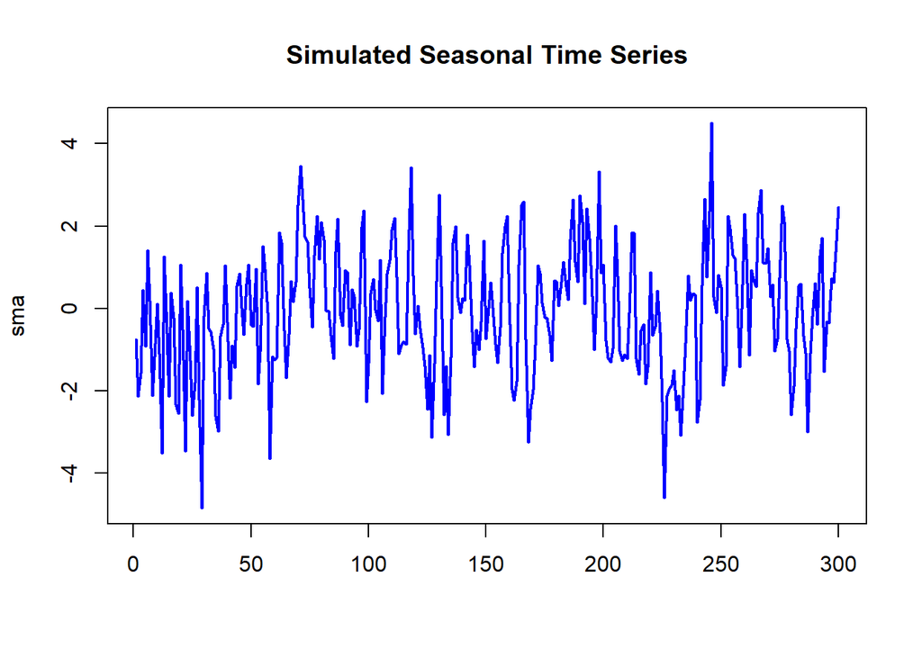

```r
   sma <- arima.sim(model = list(ma=ma_vec),n = 300)
   matplot(sma,type = "l",col = "blue",main = "Simulated Seasonal Time Series",lwd = 2)
```

Оценим ACF по ряду

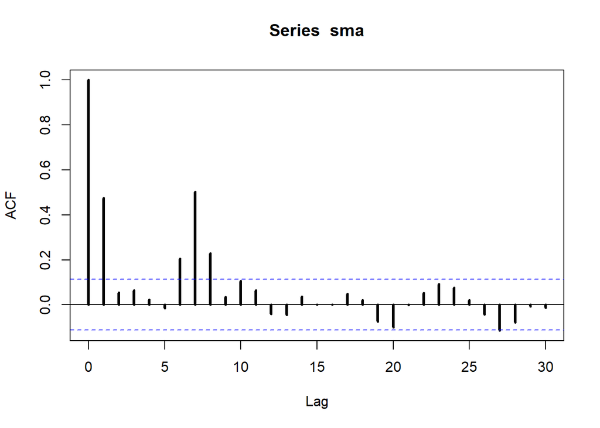

```r
acf(sma,lag.max=30,lwd = 3)
```

Для сезонного скользящего среднего произвольного порядка SARMA(0,0,q)(0,0,Q) c периодом сезонности $s$ нетрудно убедиться, что отличны от нуля будут только значения ACF на задержках
$$0,1,...,q,...,s-q,...,s-1,s,s+1,...,s+q,....,sQ-q,...,sQ-1,sQ,sQ+1,...,sQ+q$$

Для PACF без доказательсва примем на веру тот факт, что PACF процесса сезонного сколящего среднего экспоненциально затухает.

#### 1.0.2.1 Сезоннные модели авторегрессии

Здесь нам опять помогут уравнения Юла-Уокера из прошлой лекции. Из них немедленно следует, что PACF процесса SARMA(p,0)(P,0) сезонной авторегресссии с периодом сезонности $s$ вида
$$(1-\Phi_1B^s+\Phi_2B^{2S}+...+\Phi_PB^{Ps})x_t=a_t$$
$$(1-\phi_1B-\phi_2B^2-...-\phi_pB^P)a_t=\epsilon_t$$
будет отлична от нуля на задержках
$$0,1,...,p,...,s-p,...,s-1,s,s+1,...,s+p,....,sP-p,...,sP-1,sP,sP+1,...,sP+p$$

Для ACF аналогично доказывается, как и в Лекции 3,только более громоздко, что ACF представляет собой экспоненциально затухающие косинусоиды.

#### 1.0.2.2 Пример SARMA(1,0,0)(1,0,0)

Модель имеет вид
$$x_t=\Phi_1x_{t-s} +
a_t$$
$$a_t=
\phi_1a_{t-1}+\epsilon_t$$

```r
  season <- 7
  phi1 <- 0.4
  Phi1 <- -0.3
  ar <- c(1,phi1)
  sar <- c(1,rep(0,season-1),Phi1)
  ar <- as.polynomial(ar)
  sar <- as.polynomial(sar)
  ar
```

```
## 1 + 0.4*x
```

```r
  sar
```

```
## 1 - 0.3*x^7
```

```r
  sar_ar <- ar *sar
  sar_ar
```

```
## 1 + 0.4*x - 0.3*x^7 - 0.12*x^8
```

```r
  ar_vec <- sar_ar[2:length(sar_ar)]
  ar_vec
```

```
## [1]  0.40  0.00  0.00  0.00  0.00  0.00 -0.30 -0.12
```

Оценим ACF,PACF по модели

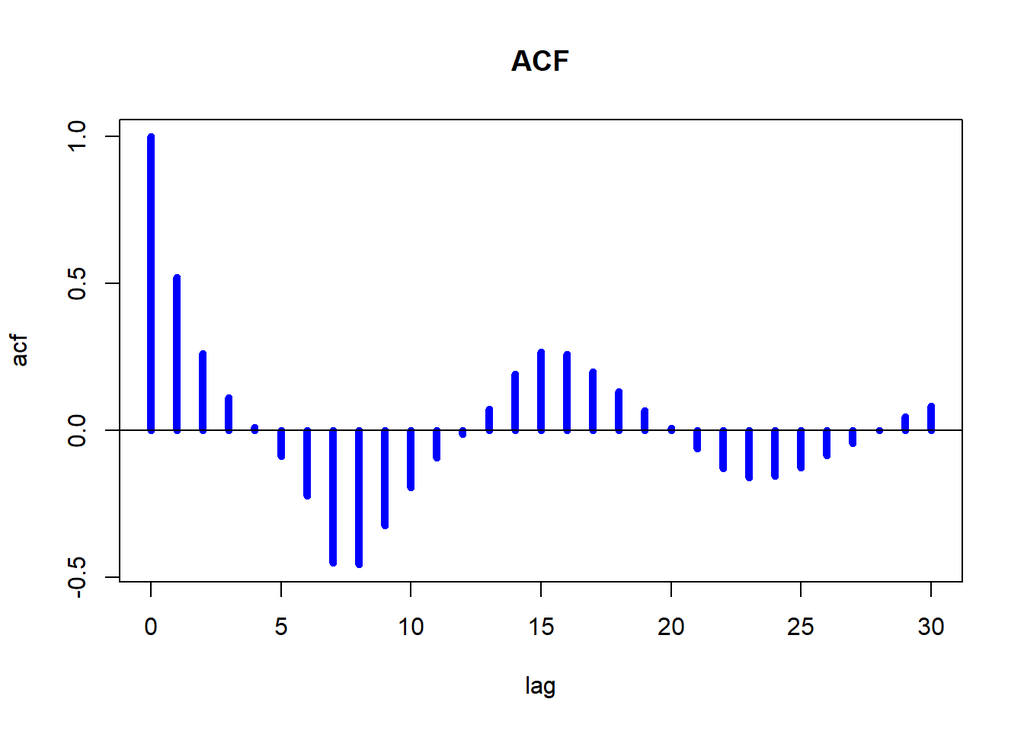

```r
  acf <- ARMAacf(ar=ar_vec,lag.max = 30,pacf = FALSE)
  pacf <- ARMAacf(ar=ar_vec,lag.max = 30,pacf = TRUE)
  m <- length(acf)
  matplot(0:(m-1),acf,type= 'h',main = 'ACF',col = 'blue',lwd = 5,xlab = 'lag',ylab='acf')
  abline(h = 0,untf = TRUE,col = 'black')
```

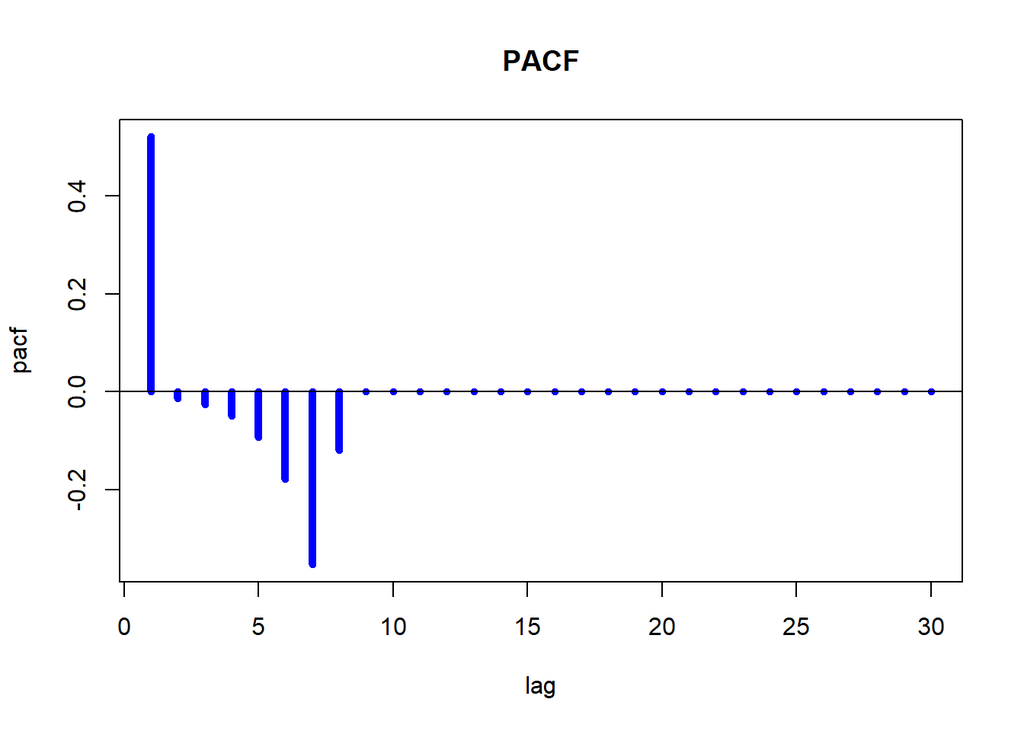

```r
  matplot(pacf,type= 'h',main = 'PACF',col = 'blue',lwd = 5,xlab =  'lag',ylab='pacf')
        abline(h = 0,untf = TRUE,col = 'black')
```

Сведем все полученные результаты по идентификации в таблицу

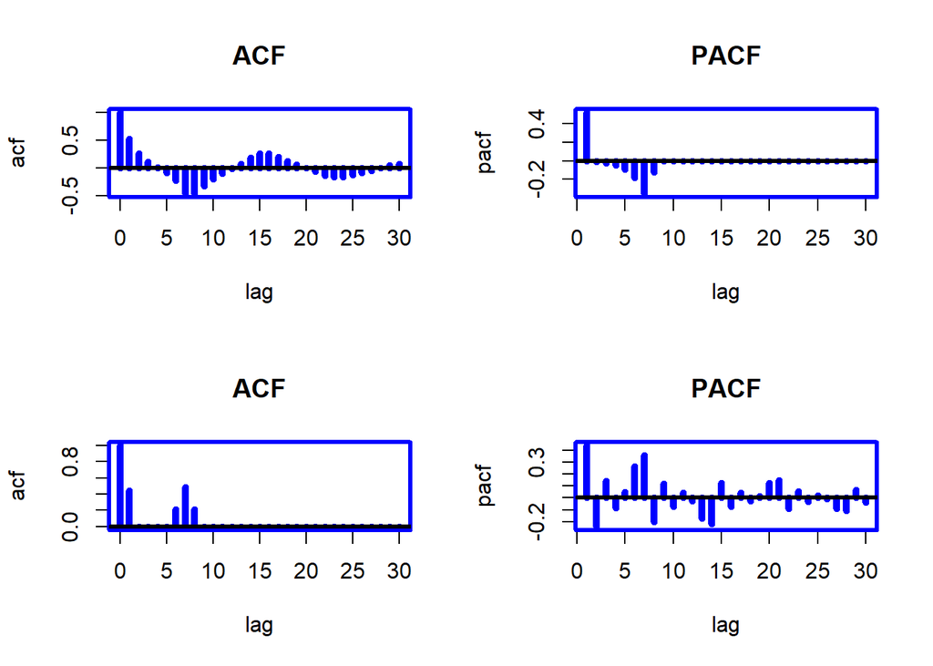

```r
  par(mfrow = c(2, 2), cex = 1.0,col = "blue",lwd = 3)
  acf <- ARMAacf(ar=ar_vec,lag.max = 30,pacf = FALSE)
  pacf <- ARMAacf(ar=ar_vec,lag.max = 30,pacf = TRUE)
  m <- length(acf)
  matplot(0:(m-1),acf,type= 'h',main = 'ACF',col = 'blue',lwd = 5,xlab =     'lag',ylab='acf')
  abline(h = 0,untf = TRUE,col = 'black')
 matplot(pacf,type= 'h',main = 'PACF',col = 'blue',lwd = 5,xlab = 'lag',ylab='pacf')
abline(h = 0,untf = TRUE,col = 'black')
 acf <- ARMAacf(ma=ma_vec,lag.max = 30,pacf = FALSE)
  m <- length(acf)
  pacf <- ARMAacf(ma=ma_vec,lag.max = 30,pacf = TRUE)
  matplot(0:(m-1),acf,type= 'h',main = 'ACF',col = 'blue',lwd = 5,xlab =     'lag',ylab='acf')
  abline(h = 0,untf = TRUE,col = 'black')
 matplot(pacf,type= 'h',main = 'PACF',col = 'blue',lwd = 5,xlab = 'lag',ylab='pacf')
abline(h = 0,untf = TRUE,col = 'black')
```

Смоделируем сезонный ряд

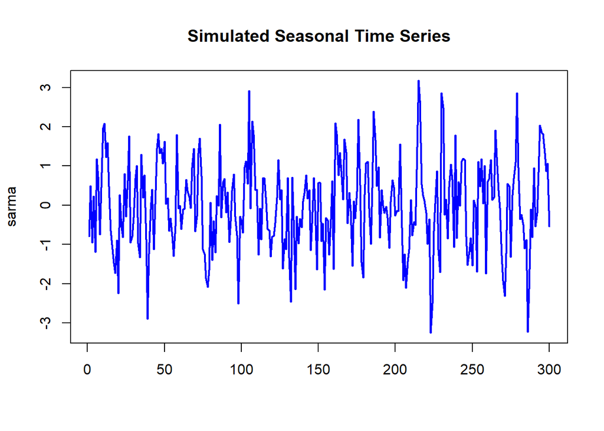

```r
   modelSAR <-list(ar = ar_vec)
   sarma <- arima.sim(model = modelSAR,n = 300)
   matplot(sarma,type = "l",col = "blue",main = "Simulated Seasonal Time Series",lwd = 2)
```

Оценим ACF,PACF по ряду

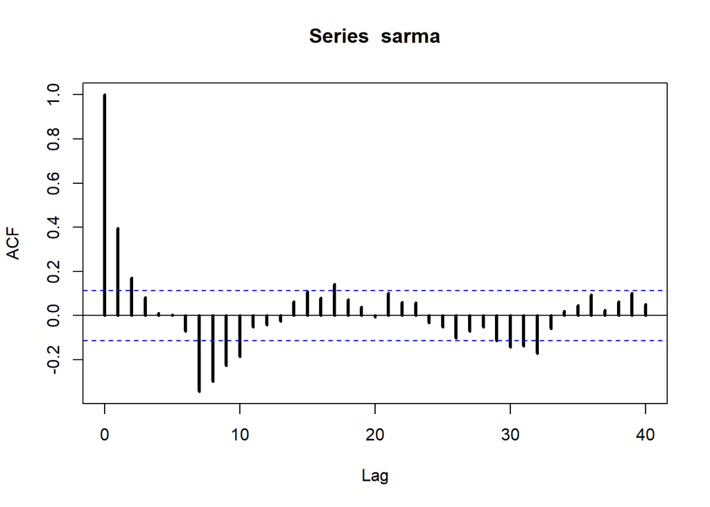

```r
acf(sarma,lag.max=40,lwd = 3)
```

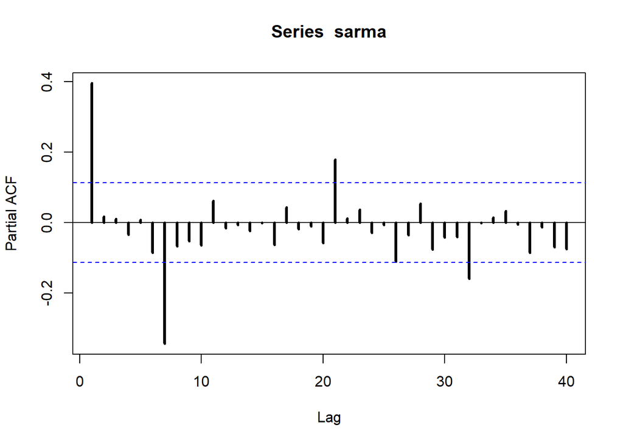

```r
pacf(sarma,lag.max=40,lwd = 3)
```

### 1.0.3 Спектрльная плотность сезонного ARMA процесса

Посмотрим на теоретическую спектральную плотность сезонного сезонного ARMA процесса.

Как и для обычного ARMA процесса она вычисляется по формуле
$$f(\lambda)= |\frac{\Theta(e^{-2\pi i\lambda
S})\theta_q(e^{-2\pi i \lambda})}{\Phi(e^{-2\pi i\lambda
S})\phi_p(e^{-2\pi i \lambda})}|^2\sigma_{\epsilon}^2$$
Для примера рассмотрим спектральную плотность сезонного AR процесса

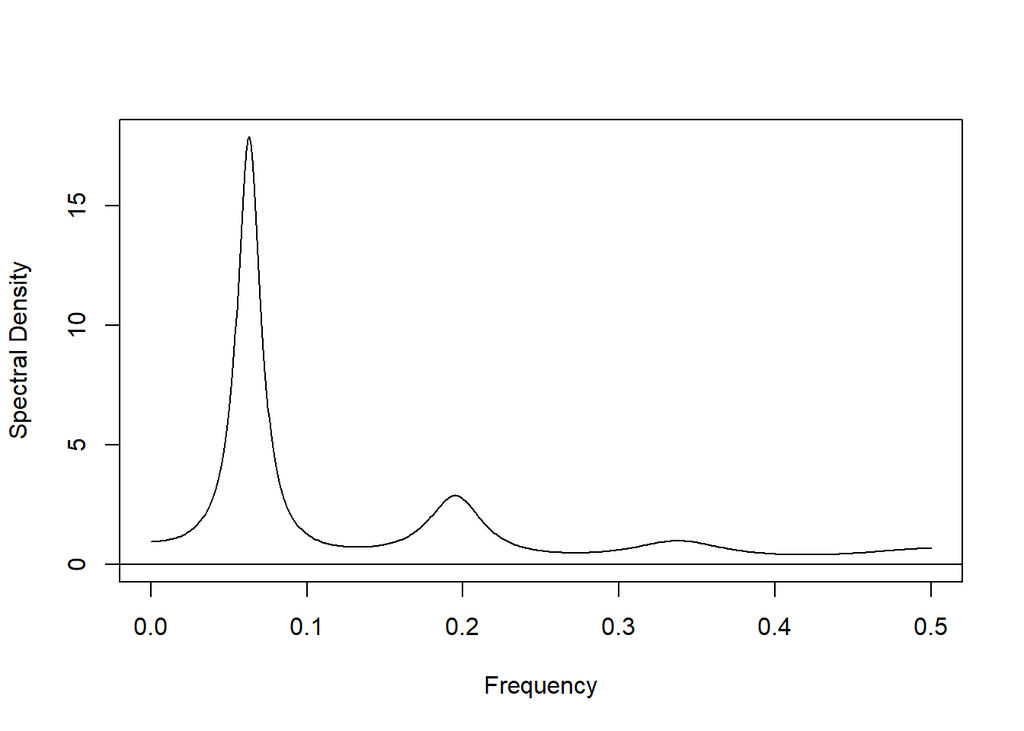

```r
library(TSA)
SARmodel <-list(ar = ar_vec)
ARMAspec(model = SARmodel)
```

Можно также не перемножать полиномы, а задать непосредственно сезонную модель. У нас уже заданы числа для параметров $\phi_1$ и $\Phi_1$ для авторегрессионой части сезонной модели. Добавим для полноты часть скользящего среднего $\theta_1=0.3$ и $\Theta_1=-0.6$.

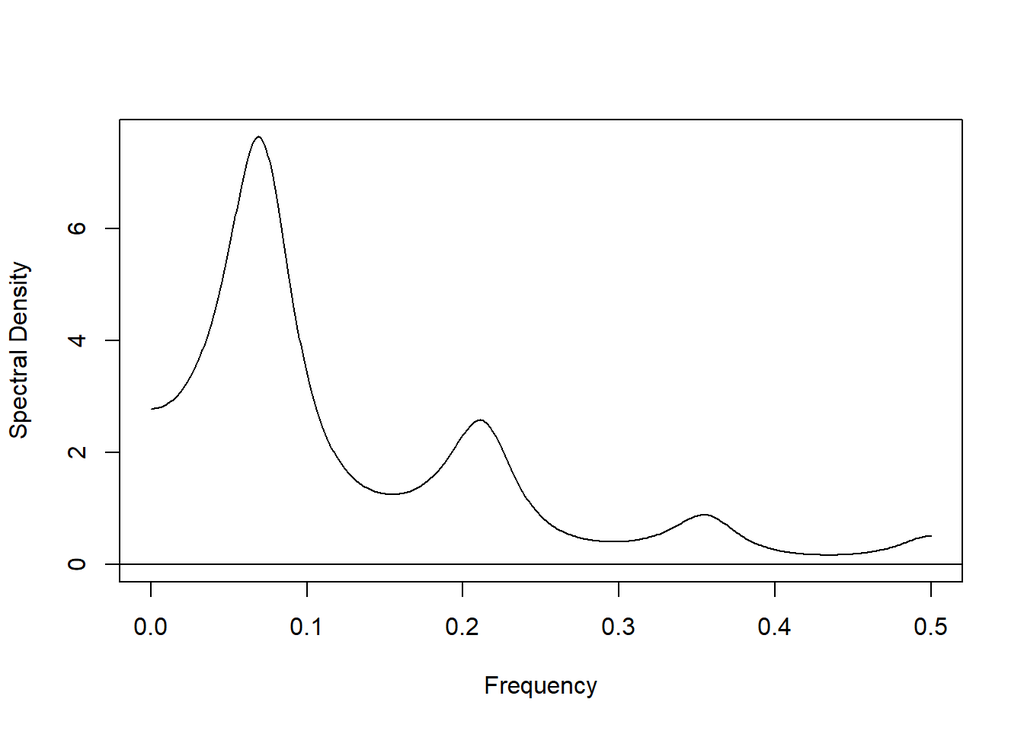

```r
theta1 <-0.3
Theta1 <- -0.6
sar_model <- list(ar = phi1,ma = theta1,seasonal=list(sar = Phi1,sar = Theta1,period = 7))
ARMAspec(model = sar_model)
```

Посмотрим сглаженную по окну Даниэлла выборочную периодограмму ранее смоделированного сезонного AR процесса.

```r
k3<- kernel('daniell',c(5,5,5))
sp=spec(sarma,kernel=k3,log='no',sub='',xlab='Frequency',
ylab='Smoothed Sample Spectral Density',col = "blue",lwd = 2)
```

[figure not shown]

Со свойствами и характерным внешним видом сезонных моделей поможет ознакомиться следующее шайни. https://shiny.ilykei.com/ANDoynikov/ARMA_Model/SAR(2,2)_%20Model/

### 1.0.4 Промышленное производство

В прошлой лекции для ряда промпроизводства мы идентифицировали 3 модели. Лучшая из них была AR(6). Вспомним критерий Акаике для 3 рассмотренных моделей

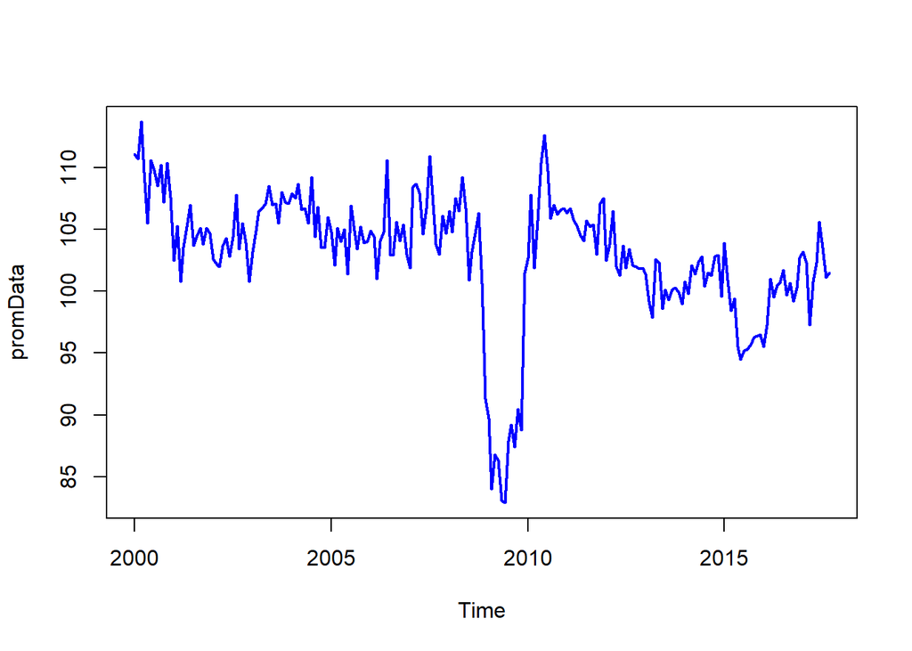

```r
promData <- read.csv("./PromProizv.csv",header = T)
promData <- ts(promData$PromProizv,start= c(2000,1),frequency = 12)
plot.ts(promData,col = "blue",lwd = 2,type = "l")
```

```r
ml_ar6 <-  arima(promData,order = c(6,0,0),method="ML")
ml_ar2 <-  arima(promData,order = c(2,0,0),method="ML")
ml_ar1_1 <-  arima(promData,order = c(1,0,1),method="ML")
ml_ar1_1$aic
```

```
## [1] 1015.986
```

```r
ml_ar2$aic
```

```
## [1] 1016.603
```

```r
ml_ar6$aic
```

```
## [1] 1007.43
```

Попробуем добавить сезонную модель. Выбор лучшей модели будем делать перебором возможных поррядков

```r
library("lmtest")
for (p in 0:4)
{
    for(q in 1:4)
    {
        tryCatch({
            model <- arima(promData,order = c(2,0,0),seasonal = list(order= c(p,0,q),period = 6 ),method = "ML")
#        coeftest(model)
        print(paste(p,q,model$aic))
        },
        error=function(error_message) {

        }
        )
    }

}
```

```
## [1] "0 1 1018.11033605977"
## [1] "0 2 971.285728887592"
## [1] "0 3 972.638930269403"
## [1] "0 4 973.406020875612"
## [1] "1 1 1001.92148759395"
## [1] "1 2 972.485591833335"
## [1] "1 3 974.088268576144"
## [1] "1 4 975.372343998997"
## [1] "2 1 992.169041377802"
## [1] "2 2 973.540117496117"
## [1] "2 3 975.539739913178"
```

```
## [1] "2 4 969.695103270267"
## [1] "3 1 990.764088561995"
## [1] "3 2 975.539077666464"
## [1] "3 3 975.205115528119"
```

```
## [1] "3 4 974.966236030239"
## [1] "4 1 987.499088335475"
## [1] "4 2 976.695233571335"
## [1] "4 3 978.73555285182"
## [1] "4 4 971.684836312243"
```

Добавление сезонной компоненты привело к значительному уменьшению значения статистики Акаике.

```r
model <- arima(promData,order = c(2,0,0),seasonal = list(order= c(0,0,2),period = 6 ),method = "ML")
coeftest(model)
```

```
##
## z test of coefficients:
##
##             Estimate Std. Error  z value  Pr(>|z|)
## ar1         0.720223   0.067240  10.7112 < 2.2e-16 ***
## ar2         0.240156   0.067450   3.5605 0.0003701 ***
## sma1       -0.075039   0.062375  -1.2030 0.2289682
## sma2       -0.636053   0.060816 -10.4586 < 2.2e-16 ***
## intercept 102.967913   1.123847  91.6209 < 2.2e-16 ***
## ---
## Signif. codes:  0 '***' 0.001 '**' 0.01 '*' 0.05 '.' 0.1 ' ' 1
```

```r
model$aic
```

```
## [1] 971.2857
```

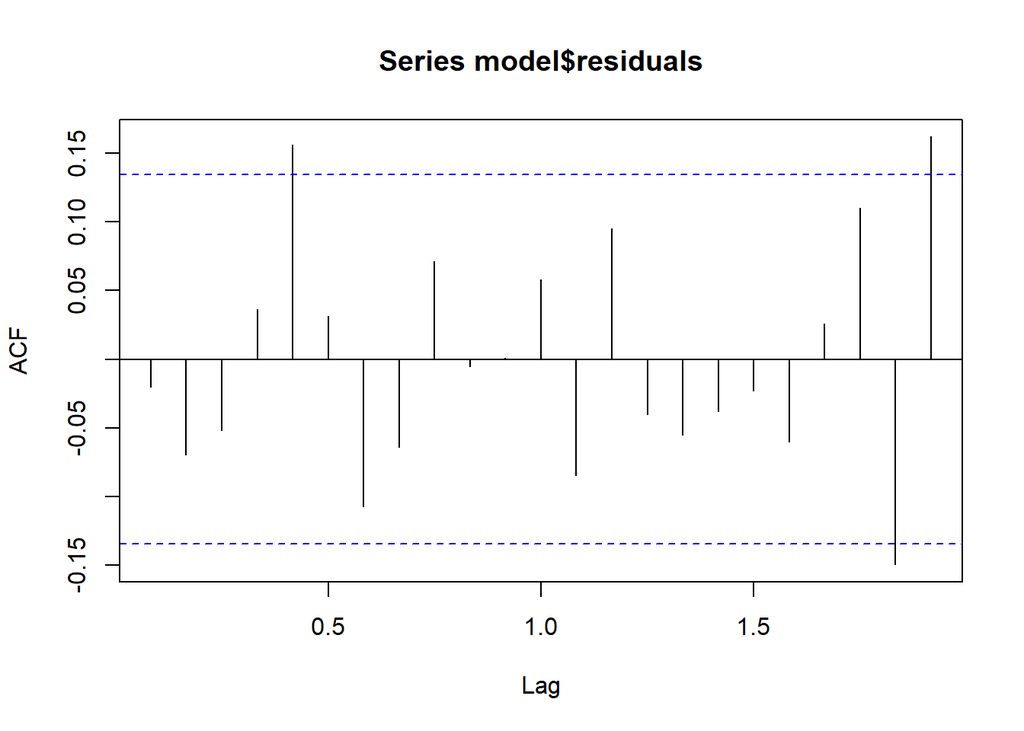

```r
acf(model$residuals)
```

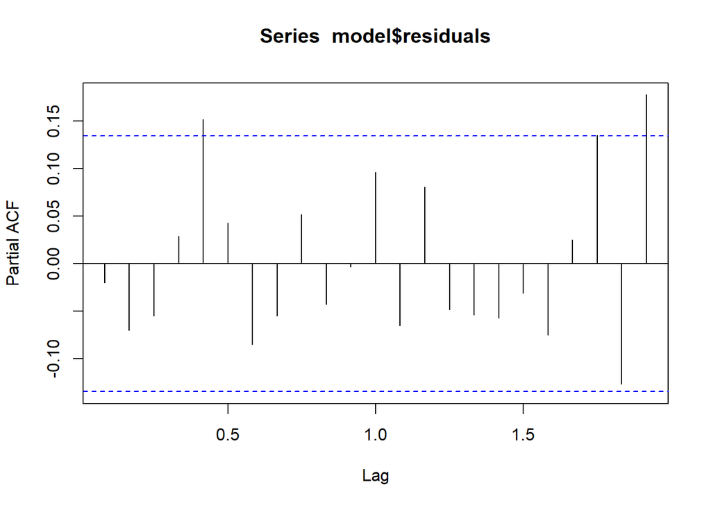

```r
pacf(model$residuals)
```

Посмотрим на тест Льюинг-Бокса

```r
Box.test(model$residuals, lag = 12, type = "Ljung-Box", fitdf = 4)
```

```
##
##  Box-Ljung test
##
## data:  model$residuals
## X-squared = 12.977, df = 8, p-value = 0.1126
```

Сравните с результатами прошлой лекции. Результат стал гораздо лучше.

Попробуем поискать модель с помощью

https://shiny.ilykei.com/ANDoynikov/ARMAMODEL4/

Сравним спектры остатков модели ARMA(2,0,0) и остатков $SARMA(2,0,0)(0,O,2)_6$

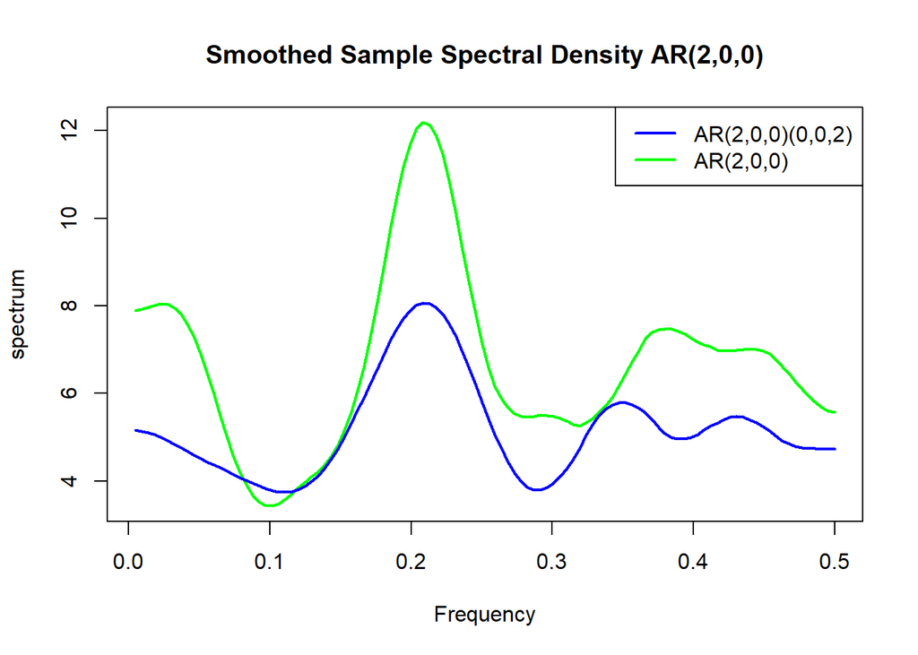

```r
k3<- kernel('daniell',c(5,5,5))
ml_ar2 <-  arima(promData,order = c(2,0,0),method="ML")
sp6=spec(ml_ar2$residuals,kernel=k3,log='no',sub='',xlab='Frequency',main = 'Smoothed Sample Spectral Density AR(2,0,0)',col = "green",lwd = 2)

sp_season=spec(model$residuals,kernel=k3,log='no',sub='',xlab='Frequency',main = 'Smoothed Sample Spectral Density AR(2,0,0)(0,0,2)',
col = "green",lwd = 2,plot=F)
#sp=spec(promData,kernel=k3,log='no',sub='',xlab='#Frequency',
#col = "blue",lwd = 2)
lines(sp_season$freq,sp_season$spec,col='blue',lwd=2)
legend("topright",c("AR(2,0,0)(0,0,2)","AR(2,0,0)"),lwd = 2,col=c("blue","green"))
```

#### 1.0.4.1 Оценка сезонных моделей

При оценке сезонных моделей используются те же методы, что и для несезонных моделей рядов. Об этом была Лекция 2. Ведь сезонные ряды это просто экономная (с точки зрения числа параметров) форма записи обычной ARMA модели. Это методы моментов (Юла-Уокера) для сезонной авторегрессии, метод наименьших квадратов и максимального правдоподобия для произвольных сезонных моделей.

Осталось только продемострировать идентификацию и оценку параметров реального экономического сезонного ряда:Импорт в млрд. долларов Российской Федерации.

Информация о динамике объемов импорта и экспорта отражается в отчете о внешнеторговом балансе государства. Внешнеторговый баланс - разница экспорта и импорта товаров. Если экспорт превышает импорт, то образуется положительное сальдо внешнеторгового баланса или внешнеторговый профицит. Если импорт превышает экспорт, то возникает отрицательное сальдо внешнеторгового баланса или внешнеторговый дефицит. В России экспорт традиционно превышает импорт за счет масштабных экспортных поставок газа, нефти и металлов. Соответственно, сальдо торгового баланса РФ сильно зависимо от мировых цен на данные сырьевые группы товаров.

Читаем данные из файла

```r
import <- read.csv("./import.csv", header = TRUE)
head(import)
```

[output not shown]

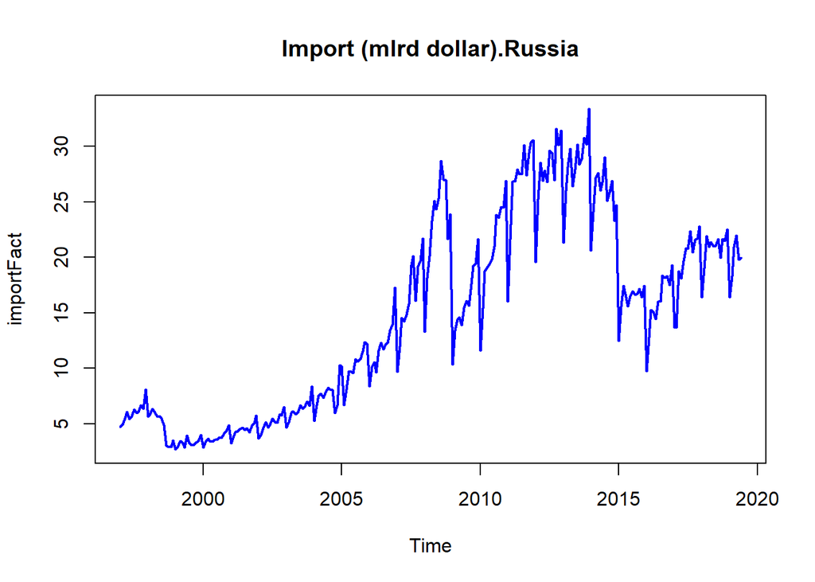

```r
importFact <- ts(import$Fact ,start= c(1997,1),frequency =12)
plot(importFact ,type = "l", col = "blue",lwd = 2,main = "Import (mlrd dollar).Russia")
```

Нестационарность явно присутствует в ряде. Возьмем обычную разность
$$y_t= x_t-x_{t-1}$$

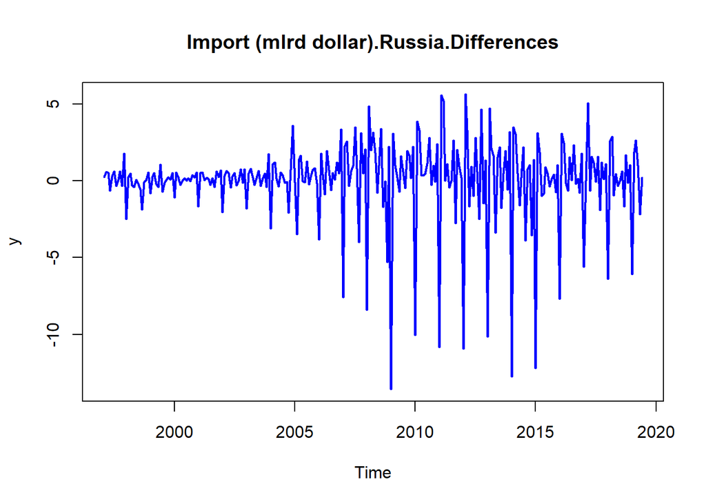

```r
y <- diff(importFact)
plot(y ,type = "l", col = "blue",lwd = 2,main = "Import (mlrd dollar).Russia.Differences")
```

Заметна нестационарность в сезонности с периодом 12. Возьмем сезонную разность
$$z_t= y_t-y_{t-12}$$

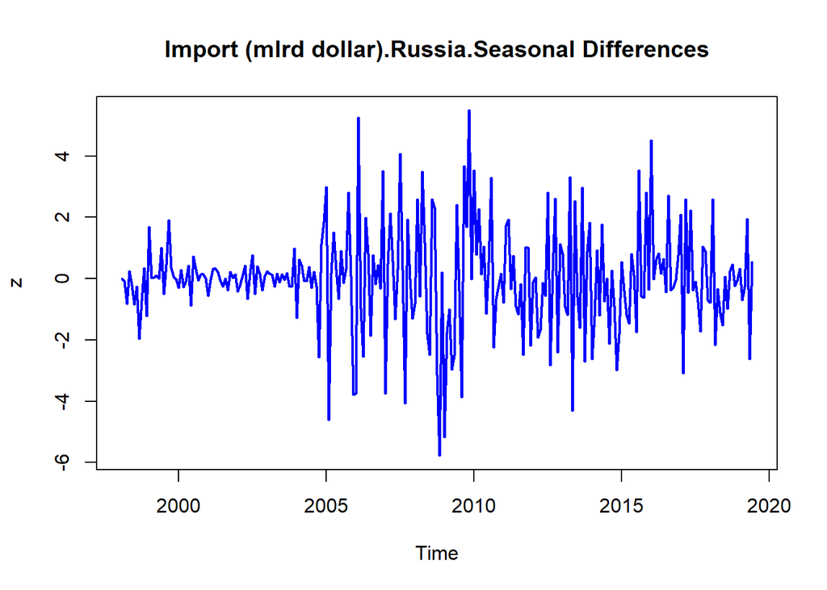

```r
z <- diff(y,lag = 12)
plot(z ,type = "l", col = "blue",lwd = 2,main = "Import (mlrd dollar).Russia.Seasonal Differences")
```

Нестационарность по дисперсии (или как сейчас принято говорить по волатильности). Но модели таких рядов мы пока не изучали. Поэтому возьмем выделим подряд с 2006 года, после которого волатильность на вид постоянна.

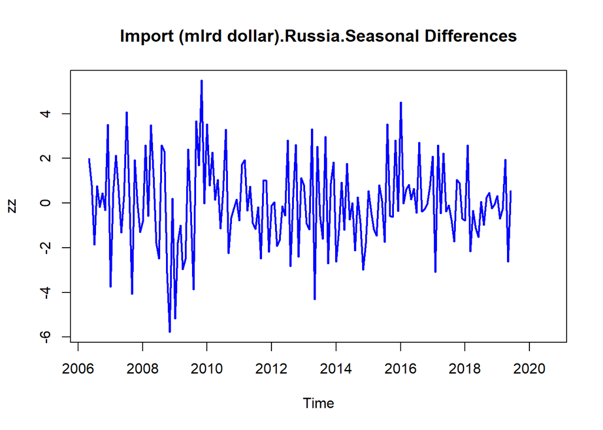

```r
zz <- z[100:271]
zz <- ts(zz,start= c(2006,5),frequency = 12 )
plot(zz ,type = "l", col = "blue",lwd = 2,main = "Import (mlrd dollar).Russia.Seasonal Differences")
```

Оценим ACF,PACF

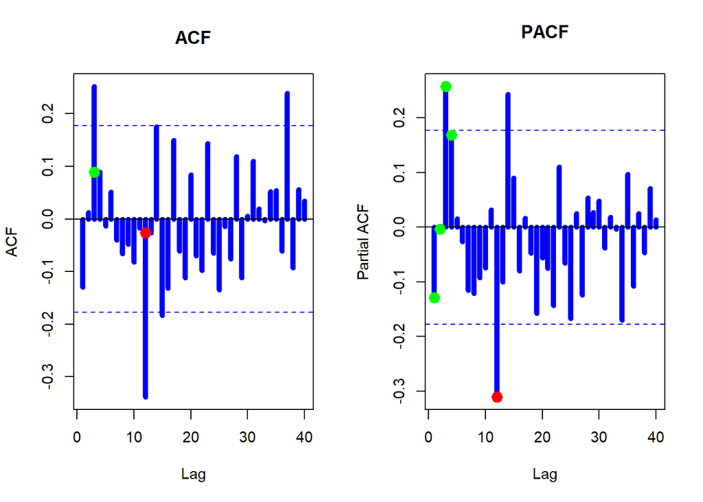

```r
zz <- zz[1:122]
par(mfrow = c(1, 2), cex = 0.9)
zacf = acf(zz, lwd = 5,main = "ACF",col = "blue",lag.max=40)
points(3,zacf$acf[4],col = "green",lwd = 5)
points(12,zacf$acf[13],col = "red",lwd = 5)
zpacf= pacf(zz,lwd = 5,main = "PACF",col = "blue",lag.max=40)
points(1:4,zpacf$acf[1:4],col = "green",lwd = 5)
points(12,zpacf$acf[12],col = "red",lwd = 5)
```

Более выразительна PACF. Попробуем оценить модель сезонной авторегрессии. Период сезонности очевидно 12. Порядок сезонной авторегрессии 1. Порядок несезонной авторегрессии 3 или 4, возьмем 4. Оцениваем эту модель методом максимального правдоподобия.

```r
modelimport <- arima(zz,order = c(4,0,0),seasonal = list(order= c(1,0,0),period = 12 ),method = "ML")
modelimport$coef
```

```
##         ar1         ar2         ar3         ar4        sar1   intercept
## -0.21314960  0.05361242  0.26716343  0.12983369 -0.36516922 -0.02593345
```

Насколько значимы оцененные параметры можно косвенно судить по ковариационной матрице оценок

```r
modelimport$var.coef
```

```
##                     ar1           ar2           ar3           ar4          sar1
## ar1        0.0081032270  0.0013973010 -0.0004900204 -0.0018619296  0.0006964960
## ar2        0.0013973010  0.0077998471  0.0012787193 -0.0004803857 -0.0005816171
## ar3       -0.0004900204  0.0012787193  0.0077894834  0.0015345285  0.0002796146
## ar4       -0.0018619296 -0.0004803857  0.0015345285  0.0079744100  0.0008899855
## sar1       0.0006964960 -0.0005816171  0.0002796146  0.0008899855  0.0075167141
## intercept  0.0002499133  0.0003809302  0.0004829565  0.0004676211  0.0005532860
##              intercept
## ar1       0.0002499133
## ar2       0.0003809302
## ar3       0.0004829565
## ar4       0.0004676211
## sar1      0.0005532860
## intercept 0.0256952317
```

P-Значения для проверки значимости вызывать отдельно или вычислять самостоятельно. Так как оценки ассимптотически нормальные, дисперсии ошибок стоят на диагонале матрицы ковариаций. Поэтому для получения р-значений для проверки значимости делаем следующую команду

```r
(1-pnorm(abs(modelimport$coef)/sqrt(diag(modelimport$var.coef))))
```

```
##          ar1          ar2          ar3          ar4         sar1    intercept
## 8.945718e-03 2.719098e-01 1.234677e-03 7.298536e-02 1.266044e-05 4.357382e-01
```

Другой способ такой проверки это метод coeftest из библиотеки lmtest

```r
library("lmtest")
coeftest(modelimport)
```

```
##
## z test of coefficients:
##
##            Estimate Std. Error z value  Pr(>|z|)
## ar1       -0.213150   0.090018 -2.3679  0.017891 *
## ar2        0.053612   0.088317  0.6070  0.543820
## ar3        0.267163   0.088258  3.0271  0.002469 **
## ar4        0.129834   0.089300  1.4539  0.145971
## sar1      -0.365169   0.086699 -4.2119 2.532e-05 ***
## intercept -0.025933   0.160297 -0.1618  0.871476
## ---
## Signif. codes:  0 '***' 0.001 '**' 0.01 '*' 0.05 '.' 0.1 ' ' 1
```

Остатки после исключения модели и усредненная сумма квадратов остатков

```r
par(mfrow = c(1, 1), cex = 0.9)
modelimport$sigma2
```

```
## [1] 3.293249
```

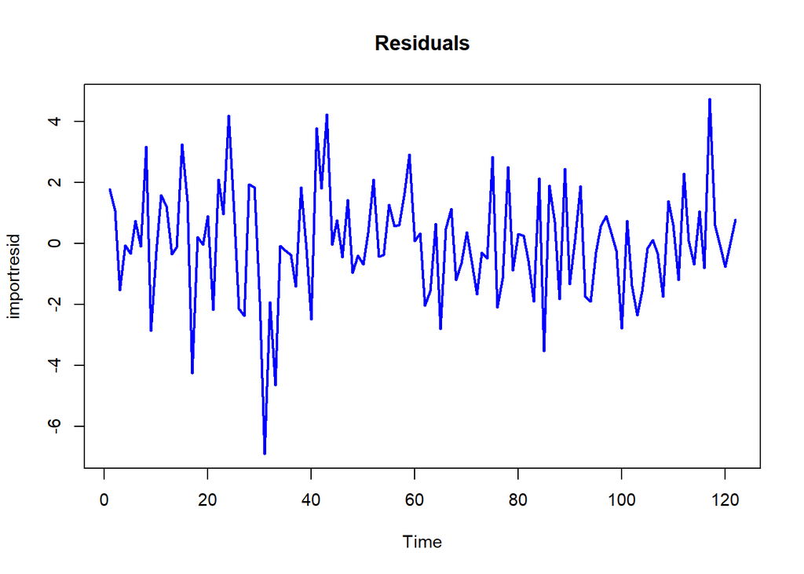

```r
importresid <- modelimport$residuals
plot(importresid ,type = "l", col = "blue",lwd = 2,main = "Residuals")
```

проведем тест Льюнг-Бокса остатков и постром qq-график

```r
  Box.test(importresid, lag = 16, type = "Ljung-Box", fitdf = 2)
```

```
##
##  Box-Ljung test
##
## data:  importresid
## X-squared = 17.32, df = 14, p-value = 0.2395
```

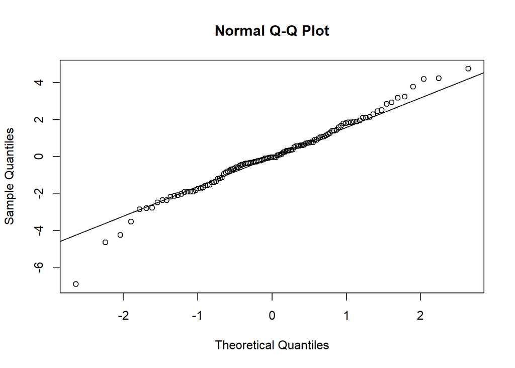

```r
  qqnorm(importresid)
  qqline(importresid)
```

Остатки явно не нормально распределены, имеют очень тяжелые хвосты Построим ACF,PACF остатков

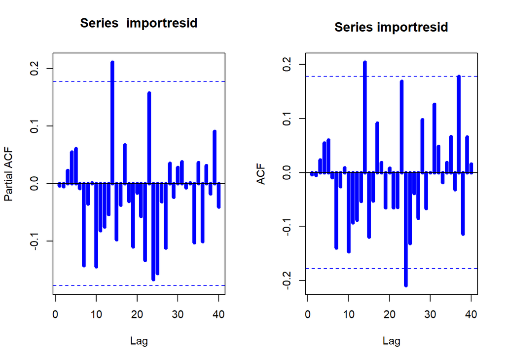

```r
par(mfrow = c(1, 2), cex = 0.9)
  pacf(importresid,lwd = 5,lag.max = 40, col = "blue")
  acf(importresid,lwd = 5,lag.max = 40, col = "blue")
```

Похоже модель выбрана не лучшим образом. Попробуем другую модель. Порядок сезонного скользящего среднего 1, а не сезонного 3. Повторим оценку уже другой модели.

```r
modelimport2 <- arima(zz,order = c(0,0,3),seasonal = list(order= c(0,0,1),period = 12 ),method = "ML")
coeftest(modelimport2)
```

```
##
## z test of coefficients:
##
##            Estimate Std. Error z value  Pr(>|z|)
## ma1       -0.267390   0.090592 -2.9516  0.003162 **
## ma2        0.041420   0.086667  0.4779  0.632707
## ma3        0.196688   0.085320  2.3053  0.021150 *
## sma1      -0.756290   0.139178 -5.4340 5.512e-08 ***
## intercept -0.056275   0.052699 -1.0679  0.285584
## ---
## Signif. codes:  0 '***' 0.001 '**' 0.01 '*' 0.05 '.' 0.1 ' ' 1
```

```r
par(mfrow = c(1, 1), cex = 0.9)
modelimport2$sigma2
```

```
## [1] 2.748341
```

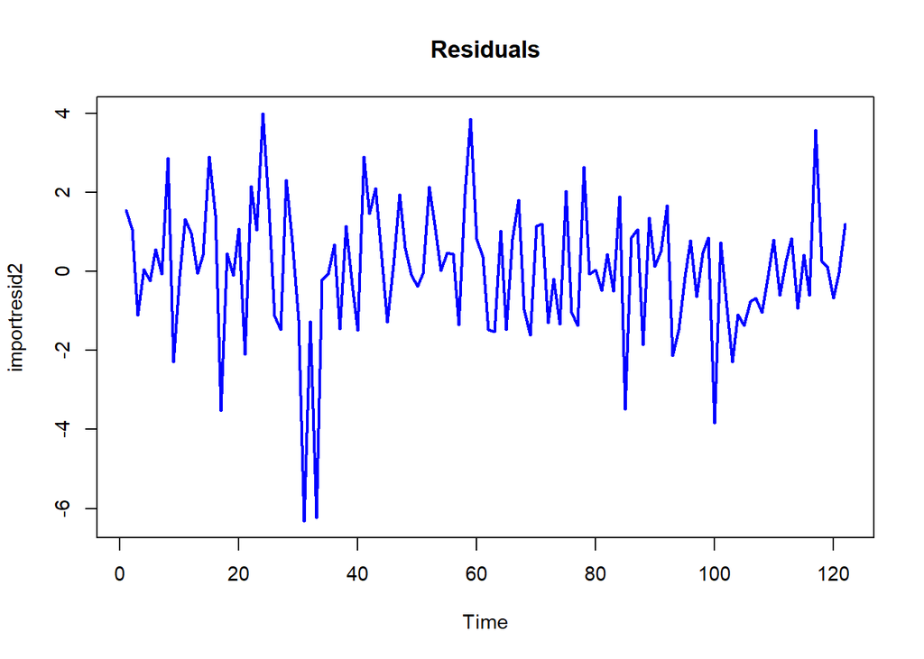

```r
importresid2 <- modelimport2$residuals
plot(importresid2 ,type = "l", col = "blue",lwd = 2,main = "Residuals")
```

```r
  Box.test(importresid2, lag = 16, type = "Ljung-Box", fitdf = 2)
```

```
##
##  Box-Ljung test
##
## data:  importresid2
## X-squared = 14.098, df = 14, p-value = 0.4424
```

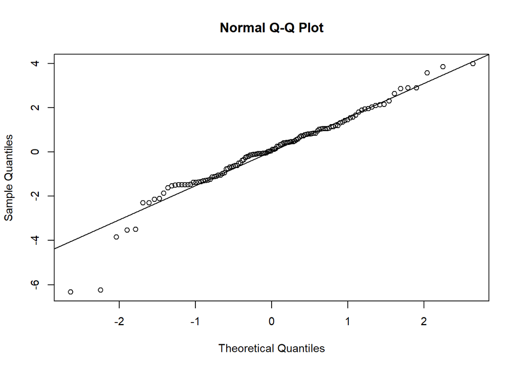

```r
  qqnorm(importresid2)
  qqline(importresid2)
```

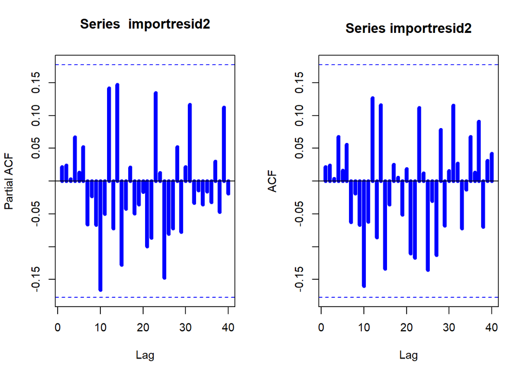

```r
par(mfrow = c(1, 2), cex = 0.9)
  pacf(importresid2,lwd = 5,lag.max = 40, col = "blue")
  acf(importresid2,lwd = 5,lag.max = 40, col = "blue")
```

Ну вот и так мы оценили достаточно адекватную модель SARMA(0,0,3)(0,0,1) остатки гипотезе, что это белый шум не противоречат, но их нормальность явно под вопросом. Тест Шапиро (см Лекцию 2.) нормальности это подтверждает, точнее гипотеза о нормальности остатков отвергается.

```r
 shapiro.test(importresid2)
```

```
##
##  Shapiro-Wilk normality test
##
## data:  importresid2
## W = 0.95343, p-value = 0.0003437
```

Посмотрим на сглаженную спектральную плотность остатков после удаления модели

```r
sp=spec(importresid2,kernel=k3,log='no',sub='',xlab='Frequency',
ylab='Smoothed Sample Spectral Density',col = "blue",lwd = 2)
```

[figure not shown]

Посмотрим на сглаженную спектральную плотность исходного ряда

Для сравнения добавим спектральную плотность остатков

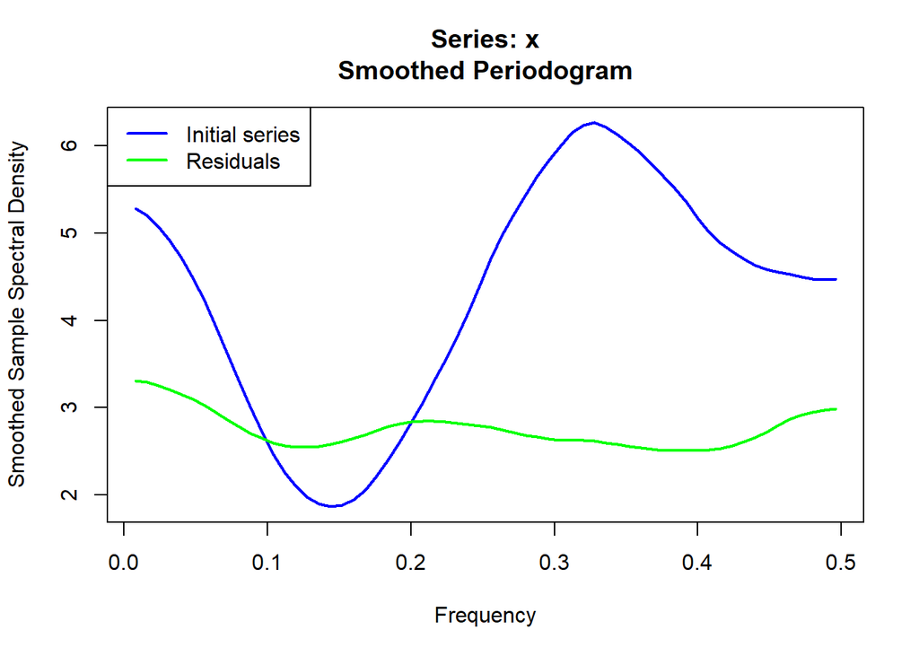

```r
k3<- kernel('daniell',c(5,5,5))

spzz=spec(zz,kernel=k3,log='no',sub='',xlab='Frequency',
ylab='Smoothed Sample Spectral Density',col = "blue",lwd = 2)
lines(sp$freq,sp$spec,col='green',lwd=2)
legend("topleft",c("Initial series","Residuals"),lwd = 2,col=c("blue","green"))
```

Выдача на один график обеих спектральных плотностей показывает, что модель действительно хорошая. Остатки ближе к белому шуму. Модель учла все основные закономерности в исходных данных

### 1.0.5 Сравнение моделей. Информационный критерий Хироцуго Акаике

Для сравнения результатов оценки по нескольким моделям и выбора лучшей из них Х.Акаике (1974) был предложен следующий критерий. В общем случае AIC:
$$\mathit{AIC} = 2k -
2\ln(L)\,$$
где $k$ — число параметров в статистической модели, и $L$ — максимизированное значение функции правдоподобия модели.

Будем полагать, что ошибки модели нормально и независимо распределены. Пусть $n$ — число наблюдений и RSS-
$$\mathit{RSS} =
\sum_{i=1}^n \hat{\varepsilon}_i^2$$
, остаточная сумма квадратов. Далее мы предполагаем, что дисперсия ошибок модели неизвестна, но одинакова для всех них. Следовательно:
$$\mathit{AIC}=2k + n[\ln(2\pi \mathit{RSS}/n) +
1]\,$$
. В случае сравнения моделей на выборках одинаковой длины, выражение можно упростить, выкидывая члены зависящие только от n:
$$\mathit{AIC}=2k +
n[\ln(\mathit{RSS})]\,$$
. Таким образом, критерий не только вознаграждает за качество приближения, но и штрафует за использование излишнего количества параметров модели. Считается, что наилучшей будет модель с наименьшим значением критерия AIC. Сравним значения критерия для двух моделей, которые мы оценили выше.

```r
  modelimport$aic
```

```
## [1] 505.6179
```

```r
  modelimport2$aic
```

```
## [1] 489.9337
```

Что потверждает наши предположения, о том, что вторая модель предпочтительней.Стоит отметить, что абсолютное значение AIC не имеет смысла — он указывает только на относительный порядок сравниваемых моделей.

# 2 Литература

- Brockwell, P. J. and Davis, R. A. (1996) Introduction to Time Series and Forecasting. Springer, New York. Sections 3.3 and 8.3.
- Бокс Дж., Дженкинс Г. (1974). Анализ временных рядов. Прогноз и управление. Пер. с англ. Вып.1-2. Мир.Москва.
- Gardner, G, Harvey, A. C. and Phillips, G. D. A. (1980) Algorithm AS154. An algorithm for exact maximum likelihood estimation of autoregressive-moving average models by means of Kalman filtering. Applied Statistics 29, 311–322.
- Hamilton J.D. (1994): Time Series Analysis. Princeton University Press.
- Harvey, A. C. (1993) Time Series Models, 2nd Edition, Harvester Wheatsheaf, sections 3.3 and 4.4.